# Medical Distribution Business Analysis Report

Hospital Consumption Data Analysis - 13 Month Study

Medical Distribution Business Analysis

2025-06-07

# 1 Executive Summary

**Current Filter:** All categories included  
**Available Categories:** Anaesthesia, Cardiology, Dermatology, Gastroenterology, General/Consumables, Miscellaneous, Ortho, Pharmaceuticals, Radiology, Respiratory, Surgical, Urology, Wound Care  
*To change filter: Modify the `selected_categories` variable in the data loading section*

## 1.1 Key Performance Indicators

862,626

Total Units Consumed

2047

Unique Products

78

Current Vendors

13

Months of Data

## 1.2 Strategic Recommendations

# 2 Market Analysis

## 2.1 ABC Classification Analysis

### 2.1.1 What is ABC Analysis?

#### 📊 ABC Analysis Definition

**ABC Analysis** is a powerful inventory management technique based on the **Pareto Principle (80/20 rule)**. It categorizes items into three classes based on their consumption value or volume:

- **Class A (High Priority):** Items that represent approximately **80% of total consumption volume** but only **20% of total items**. These are your most critical products requiring maximum attention, tight inventory control, and frequent monitoring.
- **Class B (Medium Priority):** Items representing approximately **15% of consumption volume** and **30% of items**. These require moderate control with periodic reviews and standard ordering procedures.
- **Class C (Low Priority):** Items representing only **5% of consumption volume** but **50% of total items**. These can be managed with simple controls, bulk ordering, or just-in-time delivery.

**Why ABC Analysis Matters for Your Medical Distribution Business:**

- 🎯 **Focus Resources:** Concentrate your efforts on high-impact items (Class A)
- 💰 **Optimize Cash Flow:** Invest inventory dollars where they matter most
- 📈 **Maximize ROI:** Higher service levels on items that drive revenue
- ⚡ **Efficient Operations:** Different management strategies for different item classes

ABC Classification Summary - All Categories

| ABC_Class | Items | Total_Quantity | Percentage_of_Volume |
| --- | --- | --- | --- |
| A | 206 | 689,534 | 79.934294 |
| B | 375 | 129,926 | 15.061684 |
| C | 1,466 | 43,166 | 5.004023 |

### 2.1.2 Top 20 High-Priority Items (Class A)

|  | ITEM_NAME | CATEGORY | Total_Quantity | Transaction_Count | Percentage_of_Total |
| --- | --- | --- | --- | --- | --- |
| 1 | EXAMINATION GLOVES | Surgical | 81,393 | 13 | 9.44 |
| 2 | POCT GLUCOSPOT STRIPS | Radiology | 23,000 | 7 | 2.67 |
| 3 | POCT LANCET ROUND | Radiology | 21,040 | 8 | 2.44 |
| 4 | NS 100 ML (STERIDRIP) | Pharmaceuticals | 17,223 | 8 | 2 |
| 5 | NS 100 ML | Pharmaceuticals | 16,658 | 10 | 1.93 |
| 6 | SYR 10ML BD | Pharmaceuticals | 16,320 | 8 | 1.89 |
| 7 | SYR 10 ML (NUSAFE) | Pharmaceuticals | 14,937 | 6 | 1.73 |
| 8 | PARAID-650 | Miscellaneous | 11,250 | 7 | 1.3 |
| 9 | SYR 5ML BD | Pharmaceuticals | 10,717 | 9 | 1.24 |
| 10 | NS 500 ML (STERIDRIP) | Pharmaceuticals | 10,608 | 13 | 1.23 |

[output cut: 10 more lines]

**💡 Interactive Filtering:** Use the search boxes above each column to further filter results. You can search by item name, category, or any other field to focus on specific products of interest.

### 2.1.3 ABC Analysis Visualization

[figure not shown]

## 2.2 ABC Analysis Summary & Strategic Implications

Detailed ABC Analysis Summary

| ABC_Class | Number_of_Items | Total_Volume | Avg_Volume_per_Item | Min_Volume | Max_Volume | Percentage_of_Items | Percentage_of_Volume |
| --- | --- | --- | --- | --- | --- | --- | --- |
| A | 206 | 689,534 | 3,347 | 750 | 81,393 | 10.1% | 79.9% |
| B | 375 | 129,926 | 346 | 150 | 745 | 18.3% | 15.1% |
| C | 1466 | 43,166 | 29 | 1 | 150 | 71.6% | 5% |

#### 🎯 ABC Analysis Key Findings

**Business Strategy Implications:**

- 🎯 **Immediate Action:** Secure reliable supply chains for all Class A items
- 💰 **Inventory Investment:** Allocate 80% of inventory budget to Class A items
- 📈 **Competitive Advantage:** Offer superior service levels on high-volume items
- ⚡ **Quick Wins:** Focus sales efforts on Class A items for fastest revenue growth

**Operational Recommendations:**

- **Class A:** Daily monitoring, safety stock, multiple suppliers, premium service
- **Class B:** Weekly reviews, standard inventory policies, regular supplier relationships
- **Class C:** Monthly/quarterly reviews, bulk ordering, consider dropshipping

```
# Category Performance Analysis
```

#### Category Performance Analysis - All Categories

[output not shown]

**🔍 Category Filtering Options:**  
To focus on specific categories, modify the `selected_categories` variable at the top of the report:

```
selected_categories <-
c(“Pharmaceuticals”, “Surgical”)
```

*Current filter: None (all categories shown)*

## 2.3 Category Distribution Visualization

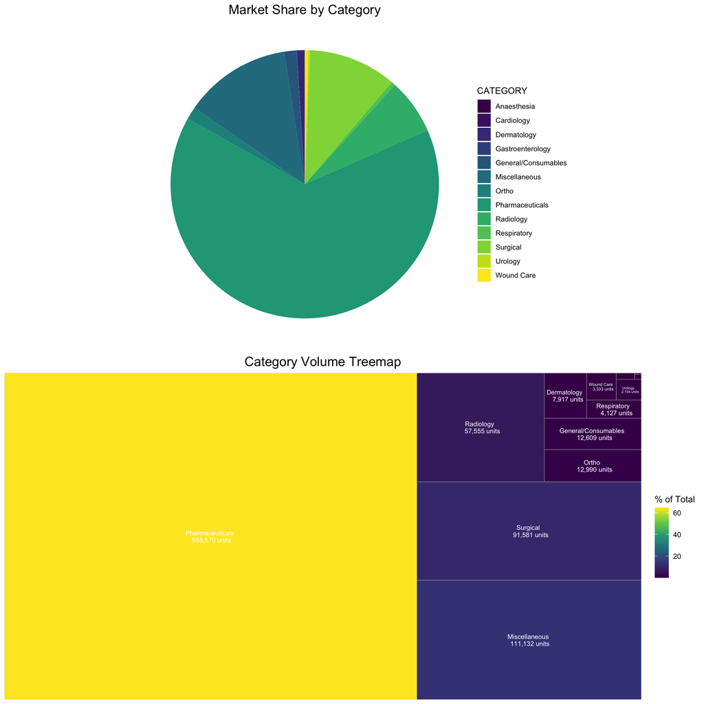

# 3 Vendor Analysis

Top 15 Vendors by Volume - All Categories

| VENDOR | Total_Transactions | Total_Quantity | Unique_Items | Categories_Served | Avg_Transaction_Size | Market_Share | Vendor_Type |
| --- | --- | --- | --- | --- | --- | --- | --- |
| R&R SURGICALS | 950 | 262,144.0 | 383 | 13 | 275.9 | 30.39 | Major Supplier |
| V K MEDICALS | 349 | 198,951.0 | 129 | 5 | 570.1 | 23.06 | Major Supplier |
| KRISHNA PHARMACEUTICAL DISTRIBUTORS | 1432 | 145,124.0 | 621 | 10 | 101.3 | 16.82 | Major Supplier |
| LAALITHYAM HOSPITALS PVT LTD | 538 | 63,173.5 | 353 | 11 | 117.4 | 7.32 | Significant Supplier |
| KUMAR MEDINEEDS | 105 | 44,177.0 | 29 | 2 | 420.7 | 5.12 | Significant Supplier |
| HEALTH PHARMA | 437 | 28,442.0 | 187 | 7 | 65.1 | 3.30 | Regular Supplier |
| SUMAN AGENCIES HYD PRIVATE LIMITED | 143 | 22,555.5 | 124 | 5 | 157.7 | 2.61 | Regular Supplier |
| KODANDAPANI MEDICALS | 29 | 15,543.0 | 15 | 2 | 536.0 | 1.80 | Regular Supplier |
| DELIGHT BIO PHARMA PVT LTD | 31 | 10,295.0 | 19 | 2 | 332.1 | 1.19 | Regular Supplier |
| VEER HEALTH CARE | 92 | 9,949.0 | 92 | 4 | 108.1 | 1.15 | Regular Supplier |
| CORTEX LABORATORIES PVT LTD | 20 | 9,555.0 | 20 | 3 | 477.8 | 1.11 | Regular Supplier |
| SS PHARMA | 10 | 9,550.0 | 8 | 2 | 955.0 | 1.11 | Regular Supplier |
| DITTAKAVI SERVICES | 10 | 7,500.0 | 2 | 2 | 750.0 | 0.87 | Small Supplier |
| ARKAS PHARMA PRIVATE LIMITED | 15 | 6,650.0 | 11 | 2 | 443.3 | 0.77 | Small Supplier |
| EROTAS ASSOCITES | 21 | 5,743.0 | 11 | 2 | 273.5 | 0.67 | Small Supplier |

### 3.0.1 Interactive Vendor Analysis

|  | VENDOR | Total_Transactions | Total_Quantity | Unique_Items | Categories_Served | Avg_Transaction_Size | Market_Share | Vendor_Type |
| --- | --- | --- | --- | --- | --- | --- | --- | --- |
| 1 | R&amp;R SURGICALS | 950 | 262144 | 383 | 13 | 275.9 | 30.39 | Major Supplier |
| 2 | V K MEDICALS | 349 | 198951 | 129 | 5 | 570.1 | 23.06 | Major Supplier |
| 3 | KRISHNA PHARMACEUTICAL DISTRIBUTORS | 1432 | 145124 | 621 | 10 | 101.3 | 16.82 | Major Supplier |
| 4 | LAALITHYAM HOSPITALS PVT LTD | 538 | 63173.5 | 353 | 11 | 117.4 | 7.32 | Significant Supplier |
| 5 | KUMAR MEDINEEDS | 105 | 44177 | 29 | 2 | 420.7 | 5.12 | Significant Supplier |
| 6 | HEALTH PHARMA | 437 | 28442 | 187 | 7 | 65.1 | 3.3 | Regular Supplier |
| 7 | SUMAN AGENCIES HYD PRIVATE LIMITED | 143 | 22555.5 | 124 | 5 | 157.7 | 2.61 | Regular Supplier |
| 8 | KODANDAPANI MEDICALS | 29 | 15543 | 15 | 2 | 536 | 1.8 | Regular Supplier |
| 9 | DELIGHT BIO PHARMA PVT LTD | 31 | 10295 | 19 | 2 | 332.1 | 1.19 | Regular Supplier |
| 10 | VEER HEALTH CARE | 92 | 9949 | 92 | 4 | 108.1 | 1.15 | Regular Supplier |

[output cut: 68 more lines]

## 3.1 Vendor Consolidation Opportunities

Vendor Consolidation Opportunity

| Vendors_to_Replace | Combined_Volume | Combined_Transactions | Average_Market_Share |
| --- | --- | --- | --- |
| 73 | 149,056.5 | 1,431 | 0.236704 |

**Consolidation Opportunity:** 73 smaller vendors could potentially be consolidated, representing 149,056.5 units of business opportunity.

# 4 Time Series Analysis

Monthly Consumption Trends - All Categories

| Month_Year | Total_Quantity | Transaction_Count | Unique_Items | Growth_Rate | Moving_Avg_3M |
| --- | --- | --- | --- | --- | --- |
| 2024-05 | 79,008.0 | 405 | 405 | NA | NA |
| 2024-06 | 45,026.0 | 338 | 338 | -43.0 | NA |
| 2024-07 | 106,330.0 | 448 | 448 | 136.2 | 76788 |
| 2024-08 | 75,708.0 | 309 | 309 | -28.8 | 75688 |
| 2024-09 | 95,935.0 | 438 | 438 | 26.7 | 92658 |
| 2024-10 | 69,113.0 | 305 | 305 | -28.0 | 80252 |
| 2024-11 | 43,701.0 | 309 | 309 | -36.8 | 69583 |
| 2024-12 | 67,442.5 | 469 | 469 | 54.3 | 60086 |
| 2025-01 | 62,936.0 | 399 | 399 | -6.7 | 58026 |
| 2025-02 | 59,325.5 | 372 | 372 | -5.7 | 63235 |
| 2025-03 | 53,147.0 | 333 | 333 | -10.4 | 58470 |
| 2025-04 | 30,238.5 | 279 | 279 | -43.1 | 47570 |
| 2025-05 | 74,715.5 | 401 | 401 | 147.1 | 52700 |

## 4.1 Monthly Trend Visualization

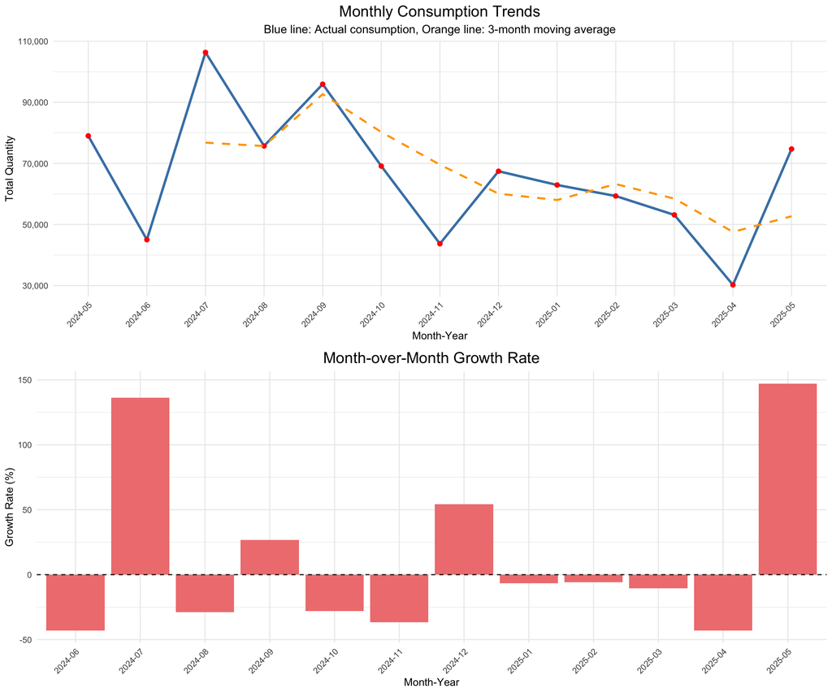

## 4.2 Category-Specific Monthly Trends

|  | Month_Year | CATEGORY | Total_Quantity | Transaction_Count |
| --- | --- | --- | --- | --- |
| 1 | 2024-05 | Cardiology | 1 | 1 |
| 2 | 2024-05 | Dermatology | 265 | 13 |
| 3 | 2024-05 | Gastroenterology | 62 | 2 |
| 4 | 2024-05 | General/Consumables | 442 | 8 |
| 5 | 2024-05 | Miscellaneous | 6835 | 90 |
| 6 | 2024-05 | Ortho | 978 | 35 |
| 7 | 2024-05 | Pharmaceuticals | 50098 | 221 |
| 8 | 2024-05 | Radiology | 11644 | 9 |
| 9 | 2024-05 | Respiratory | 40 | 3 |
| 10 | 2024-05 | Surgical | 8238 | 11 |

[output cut: 149 more lines]

## 4.3 Monthly Trend Visualization

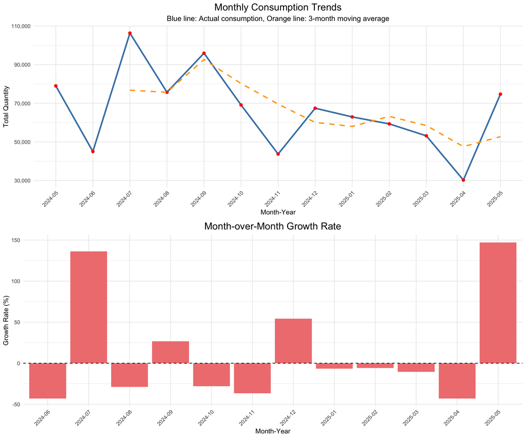

### Report Generated on 2025-06-07

This analysis is based on 13 months of actual hospital consumption data  
Total records analyzed: 4,805  
Data period: 2024-05-01 to 2025-05-01  
**Current filter: All categories included**

#### 🔧 How to Filter Categories

To analyze specific categories, modify this line in the data loading section:

```
selected_categories <- c(“Category1”,
“Category2”)
```

**Available categories:**  
“Anaesthesia”, “Cardiology”, “Dermatology”, “Gastroenterology”, “General/Consumables”, “Miscellaneous”, “Ortho”, “Pharmaceuticals”, “Radiology”, “Respiratory”, “Surgical”, “Urology”, “Wound Care”

```
selected_categories <-
c(“Pharmaceuticals”)
```

- Pharmaceuticals only  
• `selected_categories <- c(“Pharmaceuticals”, “Surgical”)` - Multiple categories  
• `selected_categories <- NULL` - All categories (default)